# Milestone_report

preethi

2/2/2020

## Introduction

This is for the capstone Datascience course.

This is done to demonstrate that we have gotten used to working with the data and that you are on track to create your prediction algorithm

1. Demonstrate that you’ve downloaded the data and have successfully loaded it in.
2. Create a basic report of summary statistics about the data sets.
3. Report any interesting findings that you amassed so far.
4. Get feedback on your plans for creating a prediction algorithm and Shiny app.

## Downloading and Extracting the Data

We need to download and extract the 3 files that are under the URL : [“https://d396qusza40orc.cloudfront.net/dsscapstone/dataset/Coursera-SwiftKey.zip”](https://d396qusza40orc.cloudfront.net/dsscapstone/dataset/Coursera-SwiftKey.zip) We will be using files under the directory EN_US There are three files under this directory

1. en_US.blogs.txt - text from blog posts
2. en_US.news.txt - text from news articles posted online
3. en_US.twitter.txt - tweets on Twitter

```r
fileUrl <-"https://d396qusza40orc.cloudfront.net/dsscapstone/dataset/Coursera-SwiftKey.zip"
if (!file.exists("Coursera-SwiftKey.zip")){
  download.file(fileUrl, destfile = "Coursera-SwiftKey.zip", method="curl")
}
unzip("Coursera-SwiftKey.zip")
```

And then we load the three text files that we want.

```r
setwd("~/R/datascience_coursera_main/Capstone/Datascience_capstone")
file1 <- file("final/en_US/en_US.blogs.txt", "rb")
blogs <- readLines(file1, encoding = "UTF-8",skipNul = TRUE)
close(file1)

file2 <- file("final/en_US/en_US.news.txt", "rb")
news <- readLines(file2, encoding = "UTF-8",skipNul = TRUE)
close(file2)

file3 <- file("final/en_US/en_US.twitter.txt", "rb")
twitter <- readLines(file3, encoding = "UTF-8",skipNul = TRUE)
close(file3)
```

Then we count the length of the lines and words in each of these files

```r
ls1 <- length(blogs)
ls2 <- length(news)
ls3 <- length(twitter)
linecount <- rbind(ls1, ls2, ls3)

library(stringi)
wordsz1 <- sum(stri_count_words(blogs))
wordsz2 <- sum(stri_count_words(news))
wordsz3 <- sum(stri_count_words(twitter))
wordcount <- rbind(wordsz1, wordsz2, wordsz3)

data.frame(source = c("blogs", "news", "twitter"),
           num.lines = c(ls1,ls2,ls3),
           num.words = c(wordsz1,wordsz2,wordsz3),
           mean.num.words = c(mean(wordsz1), mean(wordsz2), mean(wordsz3)))
```

```
##    source num.lines num.words mean.num.words
## 1   blogs    899288  37546239       37546239
## 2    news   1010242  34762395       34762395
## 3 twitter   2360148  30093413       30093413
```

```r
set.seed(5000)

sample_size = 1000

sample_blog <- blogs[sample(1:length(blogs),sample_size)]
sample_news <- news[sample(1:length(news),sample_size)]
sample_twitter <- twitter[sample(1:length(twitter),sample_size)]
data.sample <- c(sample_blog,sample_news,sample_twitter)
```

First let us create a corpus by combining the three files

```r
library(tm)
corpus <- VCorpus(VectorSource(data.sample))
toSpace <- content_transformer(function(x, pattern) gsub(pattern, " ", x))
corpus <- tm_map(corpus, toSpace, "(f|ht)tp(s?)://(.*)[.][a-z]+")
corpus <- tm_map(corpus, toSpace, "@[^\\s]+")
corpus <- tm_map(corpus, tolower)
corpus <- tm_map(corpus, removePunctuation)
corpus <- tm_map(corpus, removeNumbers)
corpus <- tm_map(corpus, stripWhitespace)
corpus <- tm_map(corpus, PlainTextDocument)
unicorpus <- tm_map(corpus, removeWords, stopwords("en"))
```

The above step is neccesary to create a function the gives you the frequencies of the different words in the form of a data frame

```r
library(dplyr)
library(plyr)
getFreq <- function(tdm) {
  freq <- sort(rowSums(as.matrix(tdm)), decreasing = TRUE)
  return(data.frame(word = names(freq), freq = freq))
}

freq1 <- getFreq(removeSparseTerms(TermDocumentMatrix(unicorpus), 0.9999))
freq2 <- getFreq(removeSparseTerms(TermDocumentMatrix(corpus), 0.9999))
```

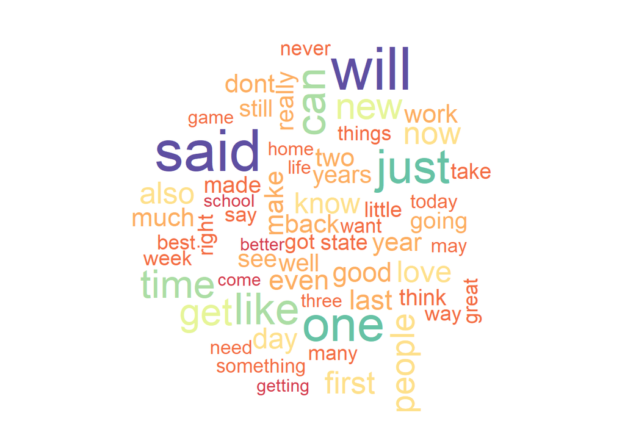

```r
library(wordcloud)
pal2 <- brewer.pal(10,"Spectral")
word_cloud1 <- wordcloud(freq1$word, freq1$freq, max.words = 60, colors=pal2)
```

```r
word_cloud1
```

```r
library(wordcloud2)
word_cloud <- wordcloud2(freq2, color = "random-light",)
word_cloud
```

[interactive chart not shown]